# Part -2:Visualizations

```python
# First, we'll import pandas, a data processing and CSV file I/O library
import pandas as pd

# We'll also import seaborn, a Python graphing library
import warnings
warnings.filterwarnings("ignore")
import seaborn as sns
import matplotlib.pyplot as plt
sns.set(style="white", color_codes=True)

# Next, we'll load the FinalMergeData dataset
data = pd.read_csv("FinalMergeData.csv")

# Let's check the data
data.head()
```

|  | Provider | BeneID | ClaimID | InscClaimAmtReimbursed | AttendingPhysician | OperatingPhysician | OtherPhysician | ClmDiagnosisCode_1 | ClmDiagnosisCode_2 | ClmDiagnosisCode_3 | ... | ChronicCond_IschemicHeart | ChronicCond_Osteoporasis | ChronicCond_rheumatoidarthritis | ChronicCond_stroke | IPAnnualReimbursementAmt | IPAnnualDeductibleAmt | OPAnnualReimbursementAmt | OPAnnualDeductibleAmt | BeneAge | PotentialFraud |
| --- | --- | --- | --- | --- | --- | --- | --- | --- | --- | --- | --- | --- | --- | --- | --- | --- | --- | --- | --- | --- | --- |
| 0 | PRV51001 | BENE86784 | CLM119495 | 10 | PHY350459 | NotApp | PHY350459 | 2767 | NotApp | NotApp | ... | 1 | 1 | 2 | 2 | 0 | 0 | 2650 | 700 | 75 | No |
| 1 | PRV51001 | BENE130029 | CLM262535 | 90 | PHY409648 | NotApp | PHY409648 | 56989 | NotApp | NotApp | ... | 1 | 2 | 2 | 1 | 7000 | 1068 | 4480 | 200 | 81 | No |
| 2 | PRV51001 | BENE102690 | CLM49733 | 42000 | PHY383193 | PHY378091 | PHY389113 | 4241 | 42731 | 4168 | ... | 1 | 2 | 1 | 2 | 143800 | 4272 | 880 | 70 | 79 | No |
| 3 | PRV51001 | BENE38773 | CLM52334 | 12000 | PHY346762 | NotApp | NotApp | 0388 | 5849 | 2841 | ... | 2 | 2 | 2 | 2 | 95000 | 2136 | 2270 | 900 | 70 | No |
| 4 | PRV51001 | BENE32715 | CLM272936 | 500 | PHY318842 | PHY392882 | NotApp | 78964 | V442 | 5589 | ... | 1 | 2 | 2 | 2 | 2020 | 1068 | 6700 | 2700 | 72 | No |

5 rows × 52 columns

```python
#check the type of data
data.dtypes
```

```
Provider                           object
BeneID                             object
ClaimID                            object
InscClaimAmtReimbursed              int64
AttendingPhysician                 object
OperatingPhysician                 object
OtherPhysician                     object
ClmDiagnosisCode_1                 object
ClmDiagnosisCode_2                 object
ClmDiagnosisCode_3                 object
ClmDiagnosisCode_4                 object
ClmDiagnosisCode_5                 object
ClmDiagnosisCode_6                 object
ClmDiagnosisCode_7                 object
ClmDiagnosisCode_8                 object
ClmDiagnosisCode_9                 object
ClmDiagnosisCode_10                object
ClmProcedureCode_1                 object
ClmProcedureCode_2                 object
ClmProcedureCode_3                 object
ClmProcedureCode_4                 object
ClmProcedureCode_5                 object
ClmProcedureCode_6                 object
DeductibleAmtPaid                   int64
ClmAdmitDiagnosisCode              object
ClaimDuration                       int64
DaysAdmitted                        int64
DiagnosisGroupCode                 object
Gender                              int64
Race                                int64
RenalDiseaseIndicator              object
State                               int64
County                              int64
NoOfMonths_PartACov                 int64
NoOfMonths_PartBCov                 int64
ChronicCond_Alzheimer               int64
ChronicCond_Heartfailure            int64
ChronicCond_KidneyDisease           int64
ChronicCond_Cancer                  int64
ChronicCond_ObstrPulmonary          int64
ChronicCond_Depression              int64
ChronicCond_Diabetes                int64
ChronicCond_IschemicHeart           int64
ChronicCond_Osteoporasis            int64
ChronicCond_rheumatoidarthritis     int64
ChronicCond_stroke                  int64
IPAnnualReimbursementAmt            int64
IPAnnualDeductibleAmt               int64
OPAnnualReimbursementAmt            int64
OPAnnualDeductibleAmt               int64
BeneAge                             int64
PotentialFraud                     object
dtype: object
```

```python
data.describe()
```

|  | InscClaimAmtReimbursed | DeductibleAmtPaid | ClaimDuration | DaysAdmitted | Gender | Race | State | County | NoOfMonths_PartACov | NoOfMonths_PartBCov | ... | ChronicCond_Diabetes | ChronicCond_IschemicHeart | ChronicCond_Osteoporasis | ChronicCond_rheumatoidarthritis | ChronicCond_stroke | IPAnnualReimbursementAmt | IPAnnualDeductibleAmt | OPAnnualReimbursementAmt | OPAnnualDeductibleAmt | BeneAge |
| --- | --- | --- | --- | --- | --- | --- | --- | --- | --- | --- | --- | --- | --- | --- | --- | --- | --- | --- | --- | --- | --- |
| count | 558211.000000 | 558211.000000 | 558211.000000 | 558211.000000 | 558211.000000 | 558211.000000 | 558211.000000 | 558211.000000 | 558211.000000 | 558211.00000 | ... | 558211.000000 | 558211.000000 | 558211.000000 | 558211.000000 | 558211.000000 | 558211.000000 | 558211.000000 | 558211.000000 | 558211.000000 | 558211.000000 |
| mean | 997.012133 | 78.294788 | 1.727940 | 0.410762 | 1.578838 | 1.255011 | 25.446969 | 378.588195 | 11.931472 | 11.93877 | ... | 1.294605 | 1.240735 | 1.682353 | 1.688829 | 1.898280 | 5227.971466 | 568.756807 | 2278.225348 | 649.698745 | 72.363624 |
| std | 3821.534891 | 273.814128 | 4.904984 | 2.112693 | 0.493746 | 0.717437 | 15.192784 | 265.215531 | 0.889712 | 0.78590 | ... | 0.455866 | 0.427530 | 0.465562 | 0.462973 | 0.302279 | 11786.274732 | 1179.172616 | 3881.846386 | 1002.020811 | 13.014302 |
| min | 0.000000 | 0.000000 | 0.000000 | 0.000000 | 1.000000 | 1.000000 | 1.000000 | 0.000000 | 0.000000 | 0.00000 | ... | 1.000000 | 1.000000 | 1.000000 | 1.000000 | 1.000000 | -8000.000000 | 0.000000 | -70.000000 | 0.000000 | 25.000000 |
| 25% | 40.000000 | 0.000000 | 0.000000 | 0.000000 | 1.000000 | 1.000000 | 11.000000 | 150.000000 | 12.000000 | 12.00000 | ... | 1.000000 | 1.000000 | 1.000000 | 1.000000 | 2.000000 | 0.000000 | 0.000000 | 460.000000 | 120.000000 | 67.000000 |
| 50% | 80.000000 | 0.000000 | 0.000000 | 0.000000 | 2.000000 | 1.000000 | 24.000000 | 350.000000 | 12.000000 | 12.00000 | ... | 1.000000 | 1.000000 | 2.000000 | 2.000000 | 2.000000 | 0.000000 | 0.000000 | 1170.000000 | 340.000000 | 73.000000 |
| 75% | 300.000000 | 0.000000 | 0.000000 | 0.000000 | 2.000000 | 1.000000 | 38.000000 | 570.000000 | 12.000000 | 12.00000 | ... | 2.000000 | 1.000000 | 2.000000 | 2.000000 | 2.000000 | 6000.000000 | 1068.000000 | 2590.000000 | 790.000000 | 81.000000 |
| max | 125000.000000 | 1068.000000 | 36.000000 | 35.000000 | 2.000000 | 5.000000 | 54.000000 | 999.000000 | 12.000000 | 12.00000 | ... | 2.000000 | 2.000000 | 2.000000 | 2.000000 | 2.000000 | 161470.000000 | 38272.000000 | 102960.000000 | 13840.000000 | 100.000000 |

8 rows × 26 columns

```python
#Load the original providers with target data
providerfraud=pd.read_csv("Train-1542865627584.csv")
```

```
Class No: 4904
Class Yes: 506
Proportion: 0.1 : 1
```

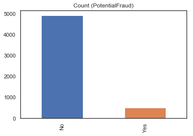

```python
target_count1 = providerfraud['PotentialFraud'].value_counts()
print('Class No:', target_count1[0])
print('Class Yes:', target_count1[1])
print('Proportion:', round(target_count1[1] / target_count1[0], 2), ': 1')

target_count1.plot(kind='bar', title='Count (PotentialFraud)');
```

Observations:There is class imbalance,there are 506 providers which are fraudulent out of 5410 providers

```
Class No: 345415
Class Yes: 212796
Proportion: 0.62 : 1
```

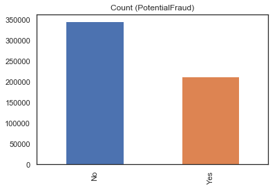

```python
target_count = data['PotentialFraud'].value_counts()
print('Class No:', target_count[0])
print('Class Yes:', target_count[1])
print('Proportion:', round(target_count[1] / target_count[0], 2), ': 1')

target_count.plot(kind='bar', title='Count (PotentialFraud)');
```

Observations:There is class imbalance in the data with proportions 0.62:1

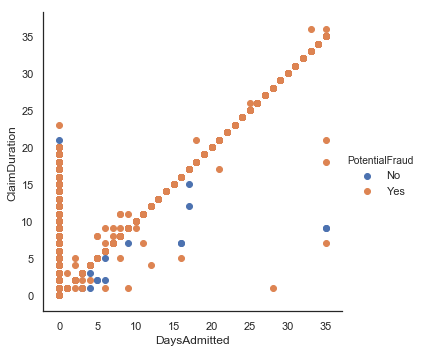

```python
# We'll use seaborn's FacetGrid to color the scatterplot by PotentialFraud
sns.FacetGrid(data, hue="PotentialFraud", size=5) \
   .map(plt.scatter, "DaysAdmitted", "ClaimDuration") \
   .add_legend()
```

Plot Explaination: We have plotted the newly generated features DaysAdmitted vs ClaimDuration wrt target classes(PotentialFraud)

Observations: We see the Number of fraudulant claims are more when ClaimDurations are greater than 0 and No.of days admitted=0(That is for an inpatient ClaimDuration being of a higher value can be an indicator for fraud)

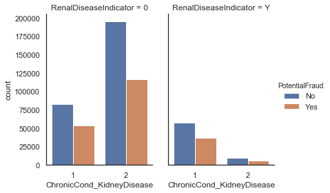

```python
 data["ChronicCond_KidneyDisease"]=data["ChronicCond_KidneyDisease"].astype('category')
g = sns.catplot(x="ChronicCond_KidneyDisease", hue="PotentialFraud", col="RenalDiseaseIndicator",
                data=data, kind="count",
                 height=4, aspect=.7);
g
```

Plot Explaination: We see the two features RenalDiseaseIndicator and ChronicCond_KidneyDisease will be dependent on each other ie,if ChronicCond_KidneyDisease is 1 then RenalDiseaseIndicator should be Y and vice versa

```python
 data["ChronicCond_Alzheimer"]=data["ChronicCond_Alzheimer"].astype('category')
data["ChronicCond_Heartfailure"]=data["ChronicCond_Heartfailure"].astype('category')
 data["ChronicCond_KidneyDisease"]=data["ChronicCond_KidneyDisease"].astype('category')
data["ChronicCond_Cancer"]=data["ChronicCond_Cancer"].astype('category')
data["ChronicCond_ObstrPulmonary"]=data["ChronicCond_ObstrPulmonary"].astype('category')
data["ChronicCond_Depression"]=data["ChronicCond_Depression"].astype('category')
data["ChronicCond_Diabetes"]=data["ChronicCond_Diabetes"].astype('category')
data["ChronicCond_IschemicHeart"]=data["ChronicCond_IschemicHeart"].astype('category')
data["ChronicCond_Osteoporasis"]=data["ChronicCond_Osteoporasis"].astype('category')
data["ChronicCond_rheumatoidarthritis"]=data["ChronicCond_rheumatoidarthritis"].astype('category')
data["ChronicCond_stroke"]=data["ChronicCond_stroke"].astype('category')
data.dtypes
```

```
Provider                             object
BeneID                               object
ClaimID                              object
InscClaimAmtReimbursed                int64
AttendingPhysician                   object
OperatingPhysician                   object
OtherPhysician                       object
ClmDiagnosisCode_1                   object
ClmDiagnosisCode_2                   object
ClmDiagnosisCode_3                   object
ClmDiagnosisCode_4                   object
ClmDiagnosisCode_5                   object
ClmDiagnosisCode_6                   object
ClmDiagnosisCode_7                   object
ClmDiagnosisCode_8                   object
ClmDiagnosisCode_9                   object
ClmDiagnosisCode_10                  object
ClmProcedureCode_1                   object
ClmProcedureCode_2                   object
ClmProcedureCode_3                   object
ClmProcedureCode_4                   object
ClmProcedureCode_5                   object
ClmProcedureCode_6                   object
DeductibleAmtPaid                     int64
ClmAdmitDiagnosisCode                object
ClaimDuration                         int64
DaysAdmitted                          int64
DiagnosisGroupCode                   object
Gender                                int64
Race                                  int64
RenalDiseaseIndicator                object
State                                 int64
County                                int64
NoOfMonths_PartACov                   int64
NoOfMonths_PartBCov                   int64
ChronicCond_Alzheimer              category
ChronicCond_Heartfailure           category
ChronicCond_KidneyDisease          category
ChronicCond_Cancer                 category
ChronicCond_ObstrPulmonary         category
ChronicCond_Depression             category
ChronicCond_Diabetes               category
ChronicCond_IschemicHeart          category
ChronicCond_Osteoporasis           category
ChronicCond_rheumatoidarthritis    category
ChronicCond_stroke                 category
IPAnnualReimbursementAmt              int64
IPAnnualDeductibleAmt                 int64
OPAnnualReimbursementAmt              int64
OPAnnualDeductibleAmt                 int64
BeneAge                               int64
PotentialFraud                       object
dtype: object
```

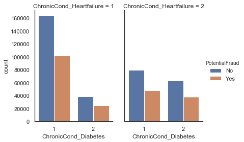

```python
g = sns.catplot(x="ChronicCond_Diabetes", hue="PotentialFraud", col="ChronicCond_Heartfailure",
                data=data, kind="count",
                 height=4, aspect=.7);
g
```

# Numeric data distribution

```python
list(set(data.dtypes.tolist()))
```

```
[dtype('O'),
 dtype('int64'),
 CategoricalDtype(categories=[1, 2], ordered=False)]
```

```python
df_num = data.select_dtypes(include = ['float64', 'int64'])
df_num.head()
```

|  | InscClaimAmtReimbursed | DeductibleAmtPaid | ClaimDuration | DaysAdmitted | Gender | Race | State | County | NoOfMonths_PartACov | NoOfMonths_PartBCov | IPAnnualReimbursementAmt | IPAnnualDeductibleAmt | OPAnnualReimbursementAmt | OPAnnualDeductibleAmt | BeneAge |
| --- | --- | --- | --- | --- | --- | --- | --- | --- | --- | --- | --- | --- | --- | --- | --- |
| 0 | 10 | 0 | 0 | 0 | 2 | 1 | 1 | 440 | 12 | 12 | 0 | 0 | 2650 | 700 | 75 |
| 1 | 90 | 0 | 0 | 0 | 2 | 1 | 1 | 660 | 12 | 12 | 7000 | 1068 | 4480 | 200 | 81 |
| 2 | 42000 | 1068 | 14 | 14 | 2 | 1 | 1 | 160 | 12 | 12 | 143800 | 4272 | 880 | 70 | 79 |
| 3 | 12000 | 1068 | 2 | 2 | 1 | 1 | 1 | 160 | 12 | 12 | 95000 | 2136 | 2270 | 900 | 70 |
| 4 | 500 | 0 | 1 | 0 | 1 | 1 | 1 | 410 | 12 | 12 | 2020 | 1068 | 6700 | 2700 | 72 |

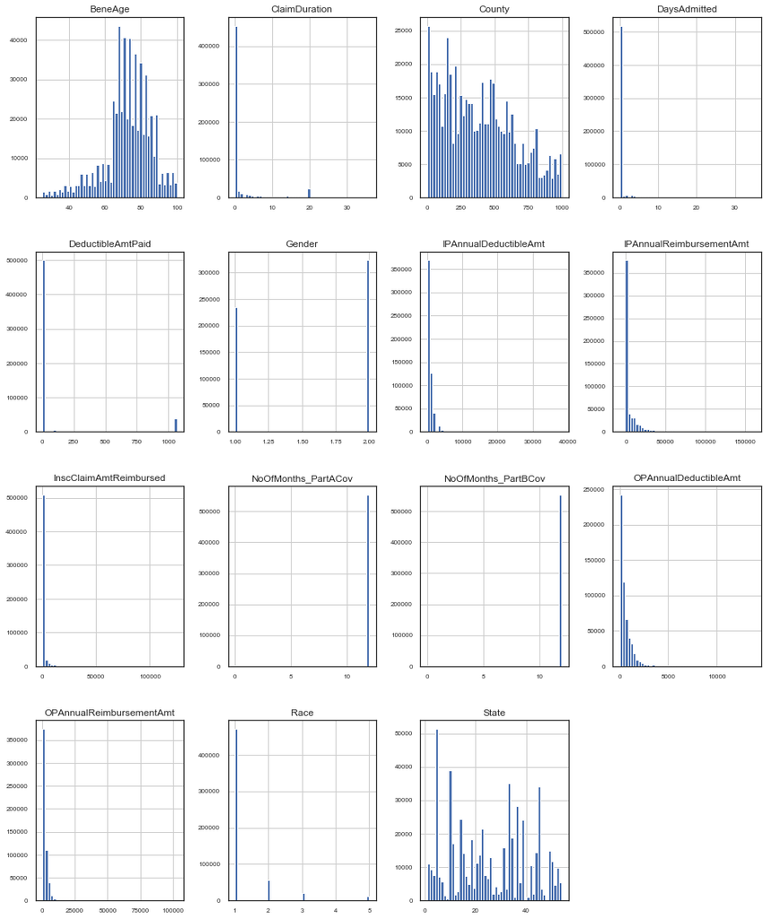

```python
df_num.hist(figsize=(16, 20), bins=50, xlabelsize=8, ylabelsize=8); # ;
```

Correlation

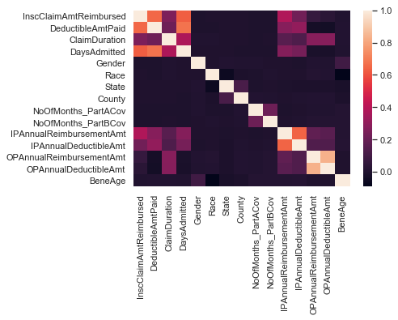

```python
import seaborn as sns
corr = data.corr()
sns.heatmap(corr,
            xticklabels=corr.columns.values,
            yticklabels=corr.columns.values)
```

Observations: Strong Correlations between (InscClaimAmtReimbursed,DeductibleAmtPaid) , (DaysAdmitted,InscClaimAmtReimbursed),(DaysAdmitted,DeductibleAmtPaid),(IPAnnualDeductibleAmt ,IPAnnualReimbursementAmt)

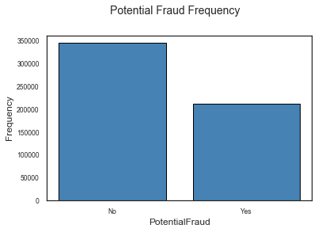

```python
# Bar Plot
fig = plt.figure(figsize = (6, 4))
title = fig.suptitle("Potential Fraud Frequency", fontsize=14)
fig.subplots_adjust(top=0.85, wspace=0.3)

ax = fig.add_subplot(1,1, 1)
ax.set_xlabel("PotentialFraud")
ax.set_ylabel("Frequency")
w_q = data['PotentialFraud'].value_counts()
w_q = (list(w_q.index), list(w_q.values))
ax.tick_params(axis='both', which='major', labelsize=8.5)
bar = ax.bar(w_q[0], w_q[1], color='steelblue',
        edgecolor='black', linewidth=1)
```

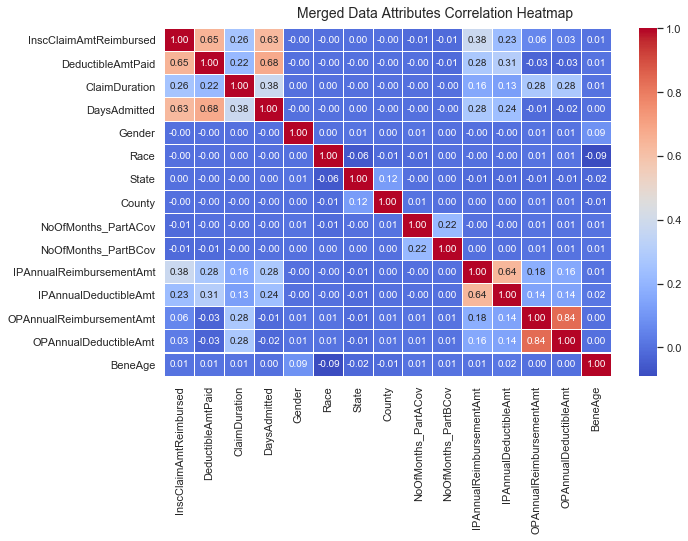

```python
# Correlation Matrix Heatmap
f, ax = plt.subplots(figsize=(10, 6))
corr = data.corr()
hm = sns.heatmap(round(corr,2), annot=True, ax=ax, cmap="coolwarm",fmt='.2f',
                 linewidths=.05)
f.subplots_adjust(top=0.93)
t= f.suptitle('Merged Data Attributes Correlation Heatmap', fontsize=14)
```

Observations: Strong Correlations between (InscClaimAmtReimbursed,DeductibleAmtPaid) , (DaysAdmitted,InscClaimAmtReimbursed),(DaysAdmitted,DeductibleAmtPaid),(IPAnnualDeductibleAmt ,IPAnnualReimbursementAmt)

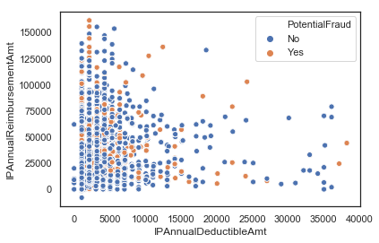

```python
sns.scatterplot(x='IPAnnualDeductibleAmt' ,y='IPAnnualReimbursementAmt',hue='PotentialFraud' ,data=data)
```

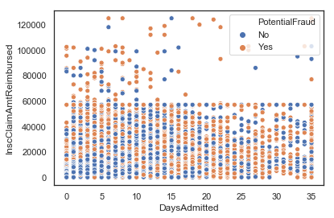

```python
sns.scatterplot(x='DaysAdmitted' ,y='InscClaimAmtReimbursed',hue='PotentialFraud' ,data=data)
```

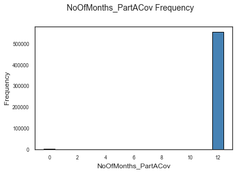

```python
# Bar Plot
fig = plt.figure(figsize = (6, 4))
title = fig.suptitle("NoOfMonths_PartACov Frequency", fontsize=14)
fig.subplots_adjust(top=0.85, wspace=0.3)

ax = fig.add_subplot(1,1, 1)
ax.set_xlabel("NoOfMonths_PartACov")
ax.set_ylabel("Frequency")
w_q = data['NoOfMonths_PartACov'].value_counts()
w_q = (list(w_q.index), list(w_q.values))
ax.tick_params(axis='both', which='major', labelsize=8.5)
bar = ax.bar(w_q[0], w_q[1], color='steelblue',
        edgecolor='black', linewidth=1)
```

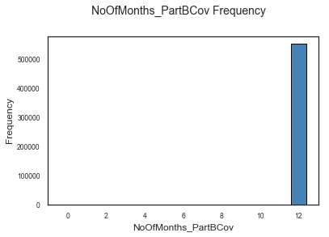

```python
# Bar Plot
fig = plt.figure(figsize = (6, 4))
title = fig.suptitle("NoOfMonths_PartBCov Frequency", fontsize=14)
fig.subplots_adjust(top=0.85, wspace=0.3)

ax = fig.add_subplot(1,1, 1)
ax.set_xlabel("NoOfMonths_PartBCov")
ax.set_ylabel("Frequency")
w_q = data['NoOfMonths_PartBCov'].value_counts()
w_q = (list(w_q.index), list(w_q.values))
ax.tick_params(axis='both', which='major', labelsize=8.5)
bar = ax.bar(w_q[0], w_q[1], color='steelblue',
        edgecolor='black', linewidth=1)
```

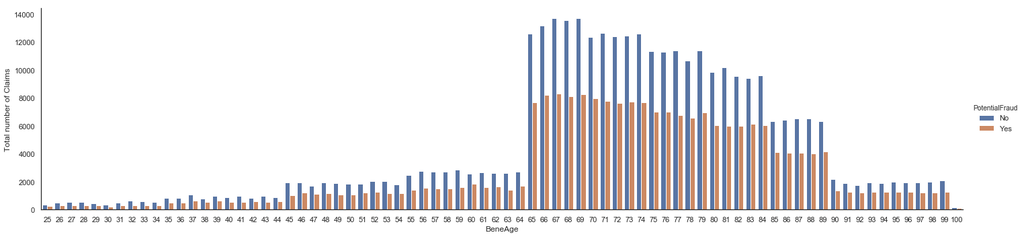

```python
with sns.axes_style('white'):
    g = sns.factorplot("BeneAge", data=data, aspect=4.0, kind='count',
                       hue='PotentialFraud')
    g.set_ylabels('Total number of Claims')
```

Observations:Most of the fraudulent claims in the data exists between age group of 65-85.